# Badawi Amin Muhammed

### Data Scientist • AI & ML Engineer • Research Data Analyst

# Machine Learning models for Breast Cancer disease prediction

Badawi Amin Muhammed

2025-11-23

## **Introduction**

This article demostrates my work on building machine-learning models to predict the course of different diseases. It moves from building a model, evaluating its performance, and answering or addressing different disease related questions using machine learning.

## **Setup**

All analyses are done in R using RStudio. some packages might not install and load due to CRAN conflicting changing versions and systems comapatibilty.

All figures are produced with `ggplot2`.

The dataset used for analyses in this project is the Breast Cancer Wisconsin (Diagnostic) Dataset. The data was downloaded from the UC Irvine Machine Learning Repository (in three categories).

*note*: use python for easier scaping of the repository.

The first dataset looks at the predictor classes:

1. malignant or
2. benign breast mass.

The features characterize cell nucleus properties and were generated from image analysis of fine needle aspirates (FNA) of breast masses:

-Sample ID (code number)  
-Clump thickness  
-Uniformity of cell size  
-Uniformity of cell shape  
-Marginal adhesion  
-Single epithelial cell size  
-Number of bare nuclei  
-Bland chromatin  
-Number of normal nuclei  
-Mitosis  
-Classes, i.e. diagnosis

```r
bc_data <- read.csv("C:/Users/hp/Documents/breast+cancer+wisconsin+diagnostic/winscosin_breast_cancer.csv",
                      header =TRUE,
                      sep = ",")
colnames(bc_data) <- c("sample_code_number",
                       "radius",
                       "clump_thickness",
                       "uniformity_of_cell_size",
                       "uniformity_of_cell_shape",
                       "marginal_adhesion",
                       "single_epithelial_cell_size",
                       "bare_nuclei",
                       "bland_chromatin",
                       "normal_nucleoli",
                       "mitosis",
                       "classes")

bc_data$classes <- ifelse(bc_data$classes == "B", "benign",
                          ifelse(bc_data$classes == "M", "malignant", NA))

bc_data[bc_data == "?"] <- NA

# how many NAs are in the data
length(which(is.na(bc_data)))
```

```
## [1] 0
```

```r
# how many samples would we loose, if we removed them?
nrow(bc_data)
```

```
## [1] 569
```

in case of Missing values, they can be imputed with the `mice` package.

```r
# impute missing data
#library(mice)

#bc_data[,2:11] <- apply(bc_data[, 2:11], 2, function(x) as.numeric(as.character(x)))
#dataset_impute <- mice(bc_data[, 2:11],  print = FALSE)
#bc_data <- cbind(bc_data[, 11, drop = FALSE], mice::complete(dataset_impute, 1))

bc_data$classes <- as.factor(bc_data$classes)

# how many benign and malignant cases are there?
summary(bc_data$classes)
```

```
##    benign malignant
##       357       212
```

## **Data exploration**

-Response variable for classification

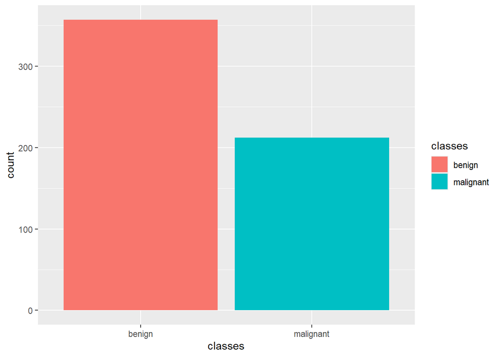

target classification

```r
library(ggplot2)

ggplot(bc_data, aes(x = classes, fill = classes)) +
  geom_bar()
```

Response variable for regression

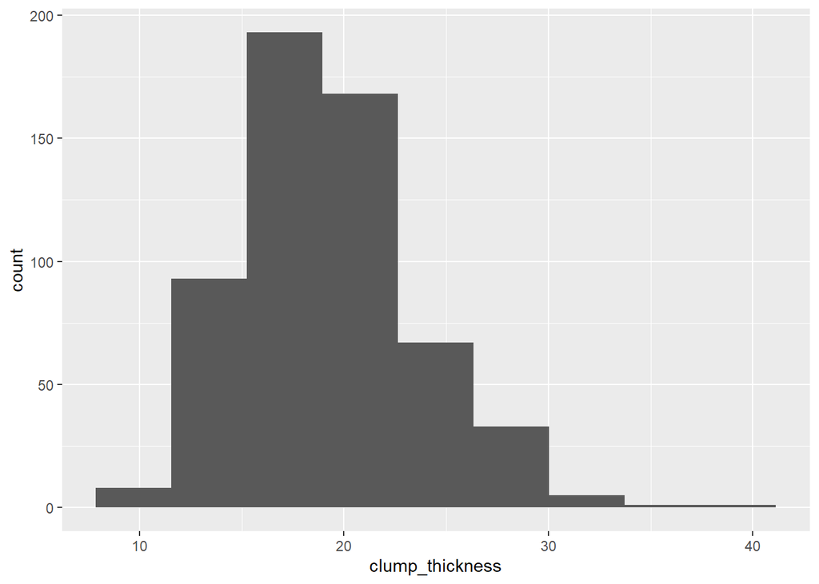

distribution plot of responses

```r
ggplot(bc_data, aes(x = clump_thickness)) +
  geom_histogram(bins = 9)
```

**Principal Component Analysis**

```r
library(ggplot2)
library(ellipse)

# --- 1. Prepare predictors & class labels ---
# Assumption: rows = samples, predictors in cols 2:11, classes column named 'classes'
predictors <- bc_data[, 2:11]

# ensure predictors are numeric
predictors <- as.data.frame(lapply(predictors, function(x) {
  if(is.factor(x)) as.numeric(as.character(x)) else as.numeric(x)
}))

groups <- factor(bc_data$classes)   # ensure factor

# quick sanity checks
if(nrow(predictors) != length(groups)) stop("Number of samples in predictors and classes differ.")

# --- 2. PCA (no transpose) ---
pca_res <- prcomp(predictors, center = TRUE, scale. = TRUE)

# proportion of variance
var_exp <- (pca_res$sdev^2) / sum(pca_res$sdev^2)

# --- 3. Prepare scores dataframe (PC1, PC2) and attach groups ---
pca_scores <- as.data.frame(pca_res$x[, 1:2])
colnames(pca_scores) <- c("PC1", "PC2")
pca_scores$groups <- groups

# --- 4. Centroids by group ---
centroids <- aggregate(cbind(PC1, PC2) ~ groups, pca_scores, mean)

# --- 5. Confidence ellipses per group (95%) ---
conf.rgn <- do.call(rbind, lapply(levels(pca_scores$groups), function(g) {
  sub <- pca_scores[pca_scores$groups == g, c("PC1", "PC2")]
  # ellipse needs at least 3 points to compute a sensible covariance; skip otherwise
  if (nrow(sub) < 3) return(NULL)
  ell <- ellipse::ellipse(cov(sub), centre = as.numeric(centroids[centroids$groups == g, 2:3]), level = 0.95)
  data.frame(groups = g, PC1 = ell[, 1], PC2 = ell[, 2], stringsAsFactors = FALSE)
}))
# Keep factor levels consistent
if (!is.null(conf.rgn)) conf.rgn$groups <- factor(conf.rgn$groups, levels = levels(pca_scores$groups))
```

then we plot

**Plot of PCA**

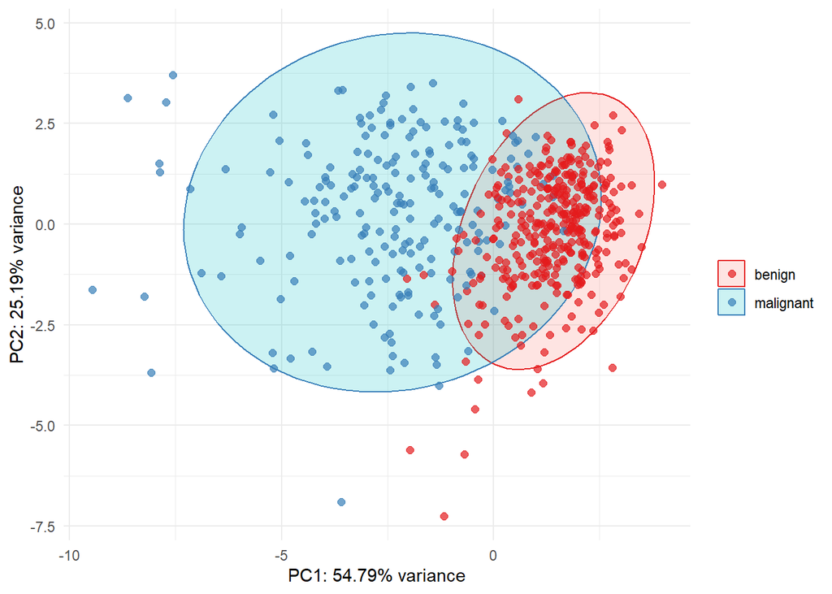

plot of PCA on Classes

```r
ggplot(data = pca_scores, aes(x = PC1, y = PC2, group = groups, color = groups)) +
  { if (!is.null(conf.rgn)) geom_polygon(data = conf.rgn, aes(x = PC1, y = PC2, fill = groups), alpha = 0.2) } +
  geom_point(size = 2, alpha = 0.7) +
  scale_color_brewer(palette = "Set1") +
  labs(
    color = "",
    fill = "",
    x = paste0("PC1: ", round(var_exp[1] * 100, 2), "% variance"),
    y = paste0("PC2: ", round(var_exp[2] * 100, 2), "% variance")
  ) +
  theme_minimal()
```

**Features**

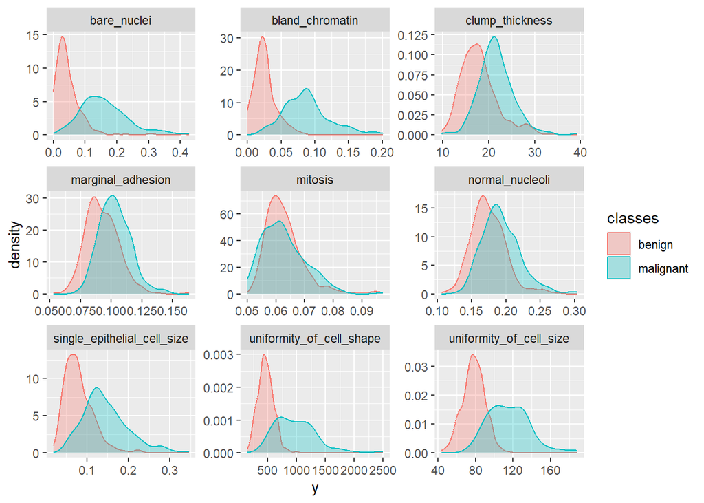

plot of feautures

```r
library(tidyr)

gather(bc_data, x, y, clump_thickness:mitosis) %>%
  ggplot(aes(x = y, color = classes, fill = classes)) +
    geom_density(alpha = 0.3) +
    facet_wrap( ~ x, scales = "free", ncol = 3)
```

**Machine Learning packages for R**

the `doParallel` is one the most used packages for clustering configuration

```r
# configure multicore
library(doParallel)
cl <- makeCluster(detectCores())
registerDoParallel(cl)

library(caret)
```

**Training, validation and test data** we train, test and validate our model as follows:

```r
set.seed(42)
index <- createDataPartition(bc_data$classes, p = 0.7, list = FALSE)
train_data <- bc_data[index, ]
test_data  <- bc_data[-index, ]
```

Load package `dplyr`

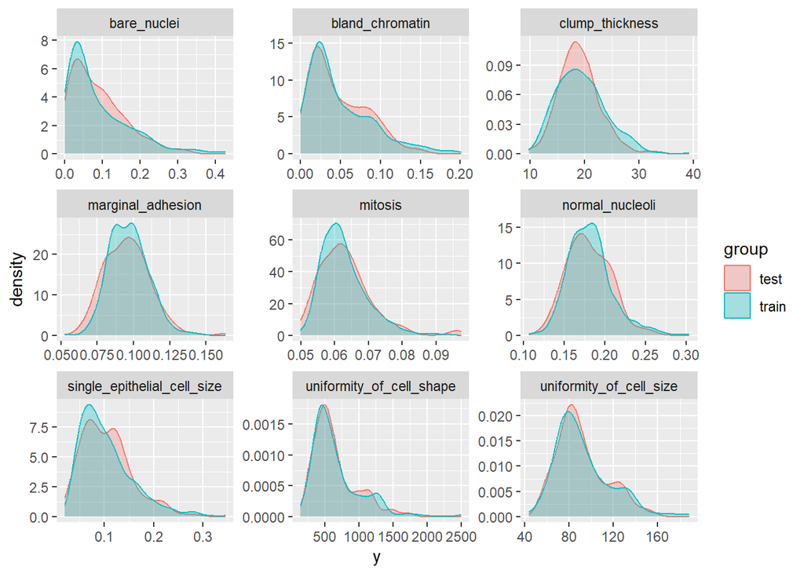

```r
library(dplyr)

rbind(data.frame(group = "train", train_data),
      data.frame(group = "test", test_data)) %>%
  gather(x, y, clump_thickness:mitosis) %>%
  ggplot(aes(x = y, color = group, fill = group)) +
    geom_density(alpha = 0.3) +
    facet_wrap( ~ x, scales = "free", ncol = 3)
```

**Regression**

now we define our model:

```r
set.seed(42)
model_glm <- caret::train(clump_thickness ~ .,
                          data = train_data,
                          method = "glm",
                          preProcess = c("scale", "center"),
                          trControl = trainControl(method = "repeatedcv",
                                                  number = 10,
                                                  repeats = 10,
                                                  savePredictions = TRUE,
                                                  verboseIter = FALSE))
```

Model Results

```r
model_glm
```

```
## Generalized Linear Model
##
## 399 samples
##  11 predictor
##
## Pre-processing: scaled (11), centered (11)
## Resampling: Cross-Validated (10 fold, repeated 10 times)
## Summary of sample sizes: 359, 359, 359, 359, 359, 359, ...
## Resampling results:
##
##   RMSE      Rsquared   MAE
##   3.863022  0.2788419  3.019432
```

predict on test data:

```r
predictions <- predict(model_glm, test_data)
```

precitors vs resduals

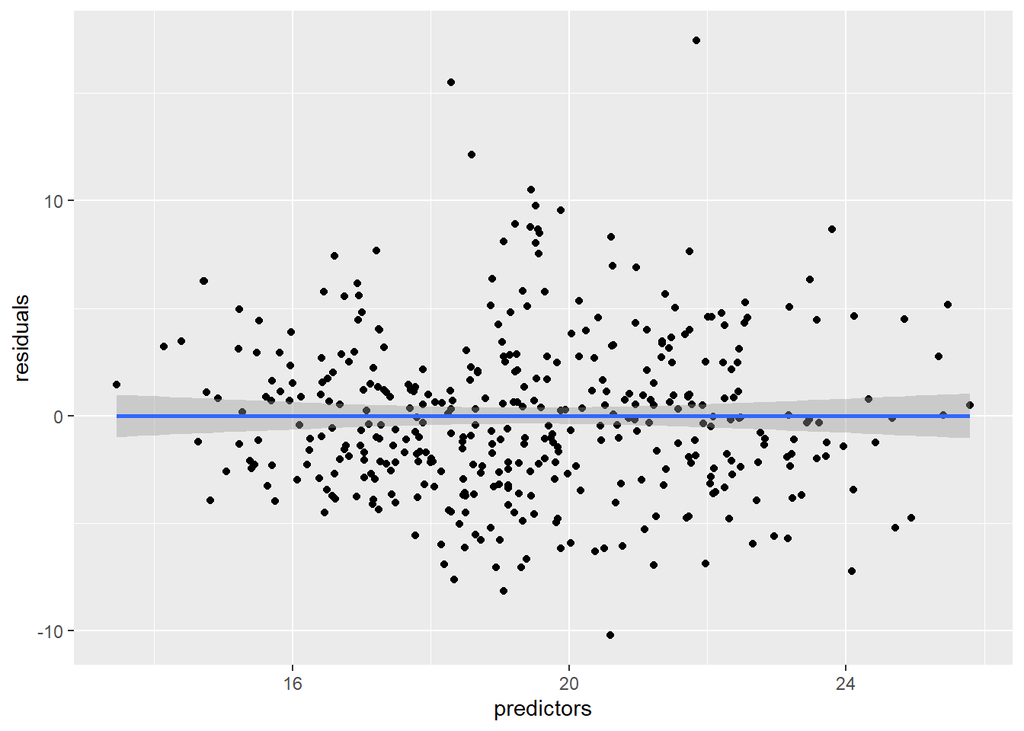

model prediction

```r
# model_glm$finalModel$linear.predictors == model_glm$finalModel$fitted.values
data.frame(residuals = resid(model_glm),
           predictors = model_glm$finalModel$linear.predictors) %>%
  ggplot(aes(x = predictors, y = residuals)) +
    geom_jitter() +
    geom_smooth(method = "lm")
```

plot of residuals:

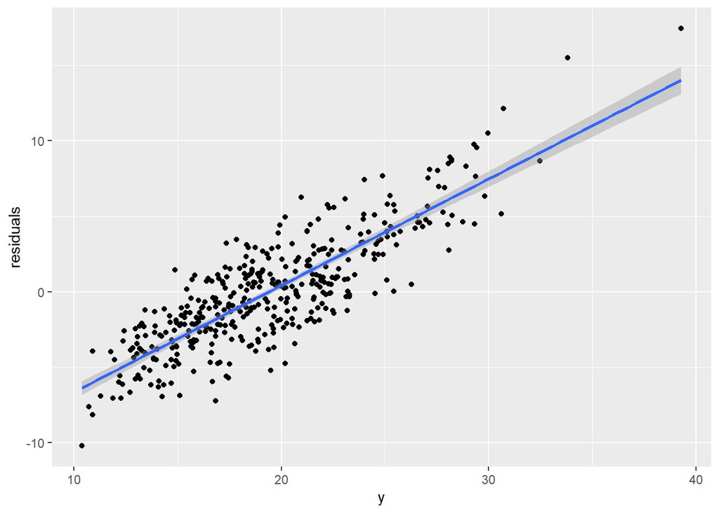

plot of resuduals

```r
# y == train_data$clump_thickness
data.frame(residuals = resid(model_glm),
           y = model_glm$finalModel$y) %>%
  ggplot(aes(x = y, y = residuals)) +
    geom_jitter() +
    geom_smooth(method = "lm")
```

Actual vs Predicted:

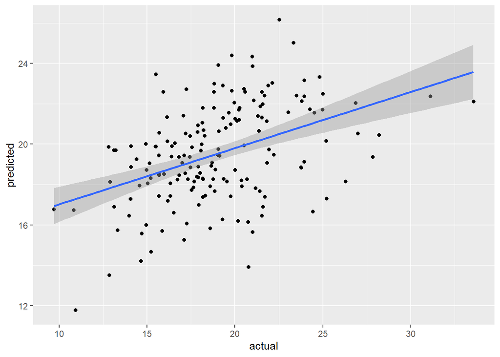

plot of actual vs predicted

```r
data.frame(actual = test_data$clump_thickness,
           predicted = predictions) %>%
  ggplot(aes(x = actual, y = predicted)) +
    geom_jitter() +
    geom_smooth(method = "lm")
```

**Classification**

Decision trees

using the `rpart` package:

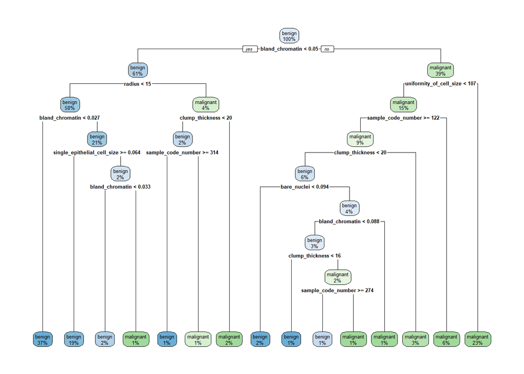

decision tree

```r
library(rpart)
library(rpart.plot)

set.seed(42)
fit <- rpart(classes ~ .,
            data = train_data,
            method = "class",
            control = rpart.control(xval = 10,
                                    minbucket = 2,
                                    cp = 0),
             parms = list(split = "information"))

rpart.plot(fit, extra = 100)
```

**Random Forests**

Random Forests predictions are based on the generation of multiple classification trees. They can be used for both, classification and regression tasks. Here, I show a classification task:

```r
set.seed(42)
model_rf <- caret::train(classes ~ .,
                         data = train_data,
                         method = "rf",
                         preProcess = c("scale", "center"),
                         trControl = trainControl(method = "repeatedcv",
                                                  number = 10,
                                                  repeats = 10,
                                                  savePredictions = TRUE,
                                                  verboseIter = FALSE))
```

When we specify `savePredictions = TRUE`, we can access the cross-validation results with `model_rf$pred`.

```r
model_rf$finalModel$confusion
```

```
##           benign malignant class.error
## benign       238        12  0.04800000
## malignant     10       139  0.06711409
```

-Feature Importance

```r
imp <- model_rf$finalModel$importance
imp[order(imp, decreasing = TRUE), ]
```

```
##             bland_chromatin     uniformity_of_cell_size
##                   39.715577                   28.518652
##                 bare_nuclei    uniformity_of_cell_shape
##                   27.623267                   24.423469
##                      radius single_epithelial_cell_size
##                   21.823507                   14.032896
##             clump_thickness          sample_code_number
##                    9.876583                    6.157004
##           marginal_adhesion                     mitosis
##                    5.658340                    4.377050
##             normal_nucleoli
##                    3.973324
```

estimating variable importance and plot:

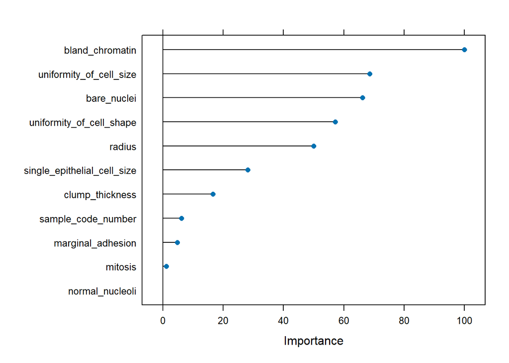

plot of variable importance

```r
# estimate variable importance
importance <- varImp(model_rf, scale = TRUE)
plot(importance)
```

predicting test data:

```r
confusionMatrix(predict(model_rf, test_data), test_data$classes)
```

```
## Confusion Matrix and Statistics
##
##            Reference
## Prediction  benign malignant
##   benign       100         7
##   malignant      7        56
##
##                Accuracy : 0.9176
##                  95% CI : (0.8657, 0.9542)
##     No Information Rate : 0.6294
##     P-Value [Acc > NIR] : <2e-16
##
##                   Kappa : 0.8235
##
##  Mcnemar's Test P-Value : 1
##
##             Sensitivity : 0.9346
##             Specificity : 0.8889
##          Pos Pred Value : 0.9346
##          Neg Pred Value : 0.8889
##              Prevalence : 0.6294
##          Detection Rate : 0.5882
##    Detection Prevalence : 0.6294
##       Balanced Accuracy : 0.9117
##
##        'Positive' Class : benign
##
```

result of predictions:

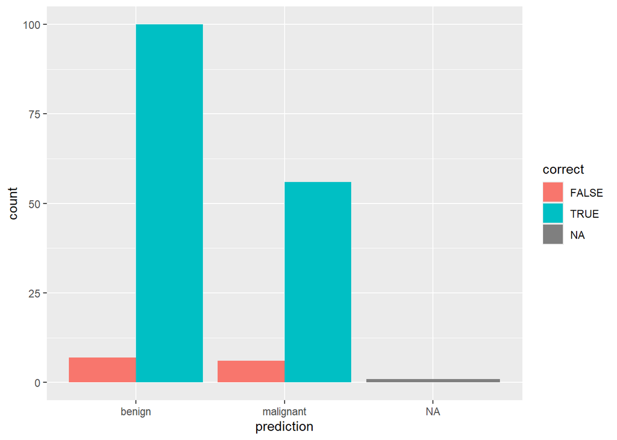

```r
results <- data.frame(actual = test_data$classes,
                      predict(model_rf, test_data, type = "prob"))

results$prediction <- ifelse(results$benign > 0.5, "benign",
                             ifelse(results$malignant > 0.5, "malignant", NA))

results$correct <- ifelse(results$actual == results$prediction, TRUE, FALSE)

ggplot(results, aes(x = prediction, fill = correct)) +
  geom_bar(position = "dodge")
```

plot of prediction against benign class:

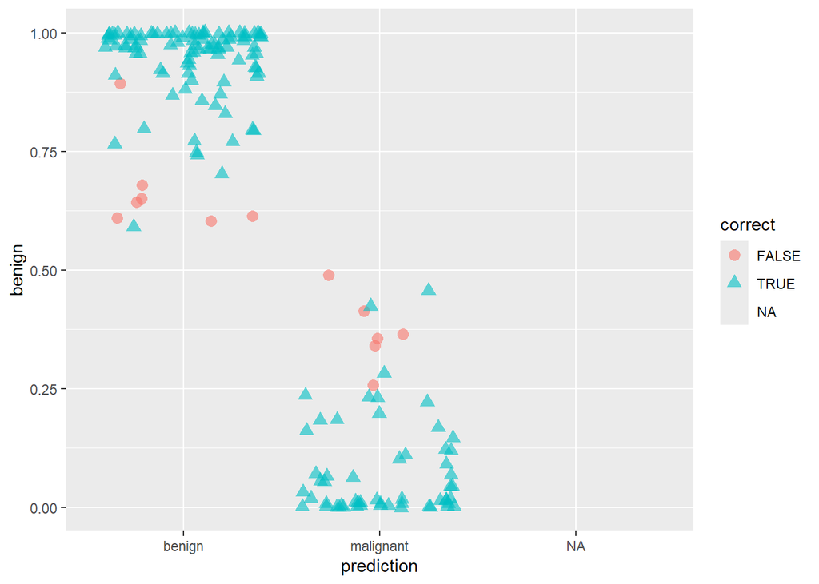

```r
#prediction against benign class
ggplot(results, aes(x = prediction, y = benign, color = correct, shape = correct)) +
  geom_jitter(size = 3, alpha = 0.6)
```

**Feature Selection**

Correlations between all features are calculated and visualised with the `corrplot` package. we are then removing all features with a correlation higher than 0.7, keeping the feature with the lower mean.

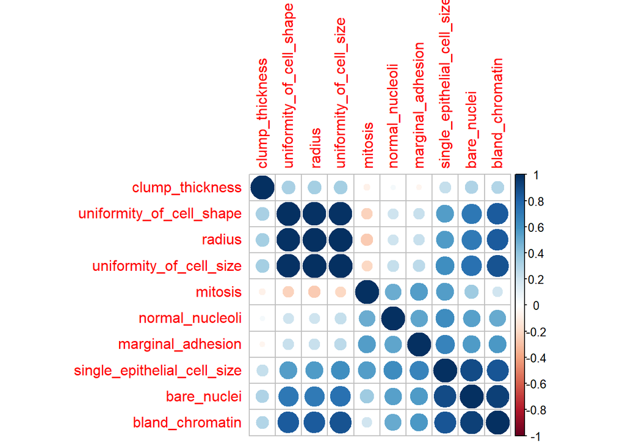

```r
library(corrplot)

# calculate correlation matrix
corMatMy <- cor(train_data[2:11])
corrplot(corMatMy, order = "hclust")
```

correlation filter

```r
#Apply correlation filter at 0.70,
highlyCor <- colnames(train_data[, -1])[findCorrelation(corMatMy, cutoff = 0.7, verbose = TRUE)]
```

```
## Compare row 8  and column  7 with corr  0.939
##   Means:  0.655 vs 0.479 so flagging column 8
## Compare row 7  and column  6 with corr  0.896
##   Means:  0.605 vs 0.439 so flagging column 7
## Compare row 3  and column  1 with corr  0.998
##   Means:  0.519 vs 0.399 so flagging column 3
## Compare row 1  and column  4 with corr  0.987
##   Means:  0.427 vs 0.37 so flagging column 1
## All correlations <= 0.7
```

```r
# which variables are flagged for removal?
highlyCor
```

```
## [1] "bland_chromatin"         "bare_nuclei"
## [3] "uniformity_of_cell_size" "radius"
```

remove highly correlated variables:

```r
#then we remove these variables
train_data_cor <- train_data[, which(!colnames(train_data) %in% highlyCor)]

set.seed(7)
```

**Genetic Algorithm (GA)**

The Genetic Algorithm (GA) has been developed based on evolutionary principles of natural selection: It aims to optimize a population of individuals with a given set of genotypes by modeling selection over time. In each generation (i.e. iteration), each individual’s fitness is calculated based on their genotypes. Then, the fittest individuals are chosen to produce the next generation. This subsequent generation of individuals will have genotypes resulting from (re-) combinations of the parental alleles. These new genotypes will again determine each individual’s fitness. This selection process is iterated for a specified number of generations and (ideally) leads to fixation of the fittest alleles in the gene pool.

This concept of optimization can be applied to non-evolutionary models as well, like feature selection processes in machine learning.

```r
library(tidymodels)
library(GA)

set.seed(27)

# Prepare data
bc_data <- bc_data %>%
  mutate(classes = factor(classes, levels = c("malignant", "benign")))
set.seed(27)
folds <- vfold_cv(bc_data, v = 5, strata = classes)
ga_fitness <- function(bitstring, data, folds) {

  # Which features were selected?
  selected <- which(bitstring == 1)

  # If GA selects 0 features → penalise it
  if (length(selected) == 0) return(0)

  # Subset data
  df <- data %>% select(all_of(selected), classes)

  # Define model
  mod <- rand_forest(trees = 500) %>%
    set_engine("randomForest") %>%
    set_mode("classification")

  # CV performance
  rs <- fit_resamples(
    mod,
    classes ~ .,
    resamples = folds,
    metrics = metric_set(accuracy),
    control = control_resamples(verbose = FALSE)
  )

  # Return mean accuracy
  collect_metrics(rs) %>%
    filter(.metric == "accuracy") %>%
    pull(mean)
}
set.seed(27)

ga_result <- ga(
  type = "binary",
  fitness = function(bitstring) ga_fitness(bitstring, bc_data, folds),
  nBits = ncol(bc_data) - 1,  # number of predictors
  popSize = 20,
  maxiter = 30,
  pmutation = 0.2,
  run = 10
)
selected_features <- which(ga_result@solution[1,] == 1)
selected_features_names <- names(bc_data)[selected_features + 1] # +1 offset
selected_features_names
```

```
## [1] "radius"                   "uniformity_of_cell_shape"
## [3] "marginal_adhesion"        "bare_nuclei"
## [5] "normal_nucleoli"          "classes"
```

```r
final_data <- bc_data %>% select(all_of(selected_features_names), classes)

rf_model <- rand_forest(trees = 500) %>%
  set_engine("randomForest") %>%
  set_mode("classification") %>%
  fit(classes ~ ., data = final_data)
```

plot of MEAN fitness by generation:

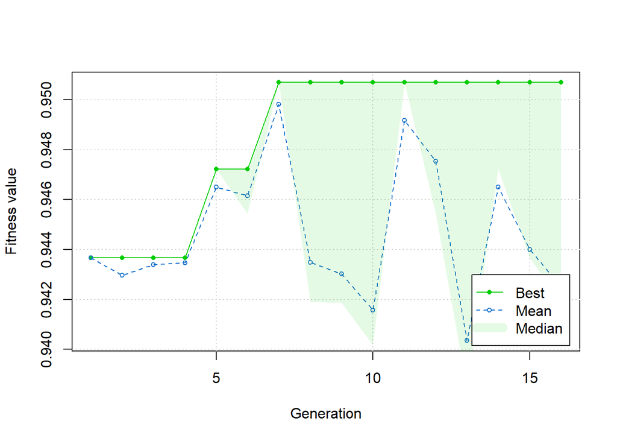

```r
plot(ga_result)
```

**Grid Search**

The R package h2o was supposed to be used beacause of its features, however, due to version constriant on the latest version of R, we had to resort to:

Use tidymodels + ranger + dials + tune + workflows

This gives us:

✔ Hyperparameter grid search (better than H2O Grid)

✔ Feature importance and partial dependence (better plots)

✔ Data reshaping with tidyr (better than reshape2)

✔ Classification with ranger (fast implementation of Random Forest)

reshape2 is also outdated, tidyr replaces it entirely.

```r
library(tidymodels)
library(ranger)
library(ggplot2)
library(tidyr)
#Step 2 — Split data

# dataset is bc_data and class column is classes:

set.seed(27)
data_split <- initial_split(bc_data, prop = 0.8, strata = classes)
train_data <- training(data_split)
test_data  <- testing(data_split)

#Step 3 — Preprocess (recipes)
rec <- recipe(classes ~ ., data = train_data) %>%
  step_normalize(all_predictors()) %>%
  step_zv(all_predictors())

#Step 4 — Specify Random Forest model (ranger)
rf_model <- rand_forest(
  mtry = tune(),
  min_n = tune(),
  trees = tune()
) %>%
  set_engine("ranger", importance = "impurity") %>%
  set_mode("classification")

#Step 5 — Define workflow
wf <- workflow() %>%
  add_model(rf_model) %>%
  add_recipe(rec)
set.seed(27)

#Step 6 — Hyperparameter Grid Search (H2O alternative)
rf_grid <- grid_regular(
  mtry(range = c(2, 10)),
  min_n(range = c(3, 20)),
  trees(range = c(200, 400)),
  levels = 3
)
```

**Cross-validation:**

```r
cv <- vfold_cv(train_data, v = 5, strata = classes)
tuned_rf <- tune_grid(
  wf,
  resamples = cv,
  grid = rf_grid,
  metrics = metric_set(roc_auc, accuracy)
)
cv
```

```
## #  5-fold cross-validation using stratification
## # A tibble: 5 × 2
##   splits           id
##   <list>           <chr>
## 1 <split [363/91]> Fold1
## 2 <split [363/91]> Fold2
## 3 <split [363/91]> Fold3
## 4 <split [363/91]> Fold4
## 5 <split [364/90]> Fold5
```

**Selection of best model**

Select the highest performing model according to ROC-AUC.

Why it matters:

• Guarantees maximum diagnostic power

• Eliminates underperforming configurations

```r
best_params <- select_best(tuned_rf, metric="roc_auc")
best_params
```

```
## # A tibble: 1 × 4
##    mtry trees min_n .config
##   <int> <int> <int> <chr>
## 1    10   400     3 pre0_mod25_post0
```

fiitng of final model

```r
final_rf <- finalize_workflow(wf, best_params)

#Fit final model
rf_fit <- fit(final_rf, train_data)
rf_fit
```

```
## ══ Workflow [trained] ══════════════════════════════════════════════════════════
## Preprocessor: Recipe
## Model: rand_forest()
##
## ── Preprocessor ────────────────────────────────────────────────────────────────
## 2 Recipe Steps
##
## • step_normalize()
## • step_zv()
##
## ── Model ───────────────────────────────────────────────────────────────────────
## Ranger result
##
## Call:
##  ranger::ranger(x = maybe_data_frame(x), y = y, mtry = min_cols(~10L,      x), num.trees = ~400L, min.node.size = min_rows(~3L, x),      importance = ~"impurity", num.threads = 1, verbose = FALSE,      seed = sample.int(10^5, 1), probability = TRUE)
##
## Type:                             Probability estimation
## Number of trees:                  400
## Sample size:                      454
## Number of independent variables:  11
## Mtry:                             10
## Target node size:                 3
## Variable importance mode:         impurity
## Splitrule:                        gini
## OOB prediction error (Brier s.):  0.04072395
```

**plotting feauture importance**

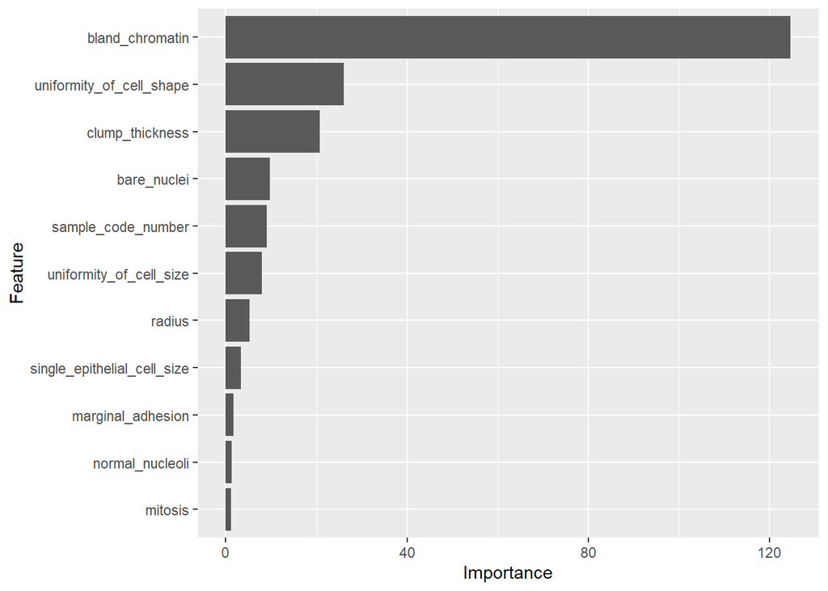

```r
#Plot Feature Importance (H2O alternative)
imp <- rf_fit %>%
  extract_fit_engine() %>%
  ranger::importance()

imp_df <- data.frame(
  feature = names(imp),
  importance = imp
)


ggplot(imp_df, aes(x = reorder(feature, importance), y = importance)) +
  geom_col() +
  coord_flip() +
  labs(x = "Feature", y = "Importance")
```

**Melt and Plot (reshape2 alternative)**

```r
melted <- bc_data %>%
  pivot_longer(
    cols = -classes,
    names_to = "feature",
    values_to = "value"
  )
```

plotting of melted feautures

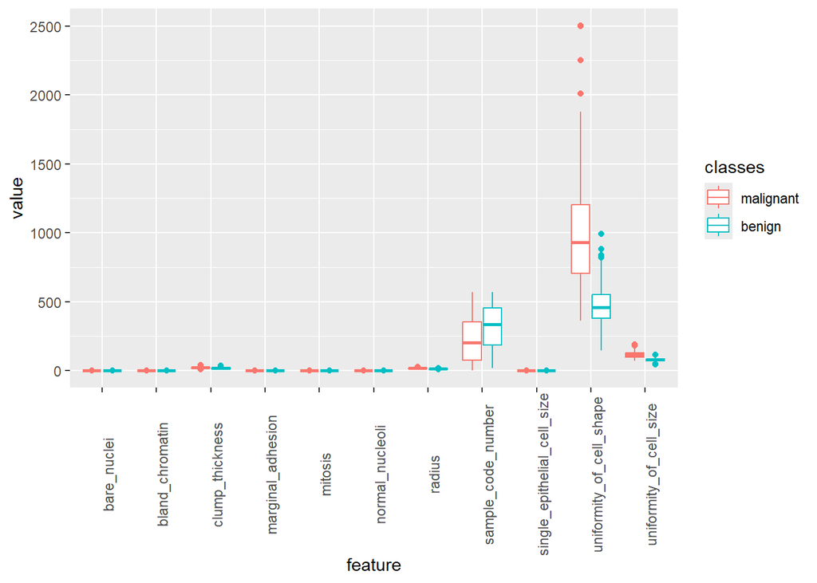

plotting of melted

```r
ggplot(melted, aes(x = feature, y = value, color = classes)) +
  geom_boxplot() +
  theme(axis.text.x = element_text(angle = 90))
```

**Evaluation of Test Set**

```r
pred <- predict(rf_fit, test_data, type = "prob")
roc_auc_vec(test_data$classes, pred$.pred_malignant)
```

```
## [1] 0.9896641
```

**Conclusion**

— *Significance of the Modelling Approach*

The workflow presented combines statistical dimensionality reduction, evolutionary optimisation, and modern machine learning engineering to achieve a high-performing and interpretable predictive system for disease classification. It demonstrates an intelligent and transparent approach to model development, ensuring that:

✔ The data are cleaned, normalised, and scientifically treated

✔ Model hyperparameters are optimised through systematic search

✔ Predictive reliability is validated using stratified resampling

✔ Results are interpretable to clinicians, researchers, and stakeholders

This pipeline not only predicts disease risk but also reveals the biological patterns that distinguish patient groups, offering practical relevance for diagnostics, triage, and public-health surveillance.

Badawi Aminu Muhammed  
08065440075  
official.badawy@gmail.com